# CHURN PREDICTION MODEL

## INTRODUCTION

Churn Prediction refers to the process of identifying customers who are likely to stop using a company’s products or services. In business, particularly in subscription-based services or retail, customer churn is a critical metric as it directly impacts revenue. The goal of a churn prediction model is to accurately forecast which customers are at risk of leaving, allowing the company to take proactive measures to retain them.

**1. IMPORT LIBRARIES AND DATASET**

In this step, we will load the dataset into our environment using pandas. Loading the data is the first step in any data science project as it allows us to work with the data directly in our notebook.

## Why Load the Data?

```python
# import necessary libraries
import pandas as pd
import numpy as np
import matplotlib.pyplot as plt
import seaborn as sns

# load the dataset
file_path = 'BankChurners.csv'  # Make sure the file is in the same directory as your notebook
data = pd.read_csv(file_path)
```

EXPLAINATION:

**2. EXPLORE AND UNDERSTAND THE DATA (EDA)**

In this step, we will perform Exploratory Data Analysis (EDA) to understand the dataset better. EDA helps us to visualize and summarize the main characteristics of the data, often with visual methods.

Why Perform EDA?

To identify patterns, trends, and anomalies in the data. To check for missing values and outliers. To understand the distribution of the data and relationships between variables.

```python
# Basic information about the dataset
data.info()

# Check for missing values
data.isnull().sum()

# Descriptive statistics of the dataset
data.describe()
```

```
<class 'pandas.core.frame.DataFrame'>
RangeIndex: 10127 entries, 0 to 10126
Data columns (total 23 columns):
 #   Column                                                                                                                              Non-Null Count  Dtype
---  ------                                                                                                                              --------------  -----
 0   CLIENTNUM                                                                                                                           10127 non-null  int64
 1   Attrition_Flag                                                                                                                      10127 non-null  object
 2   Customer_Age                                                                                                                        10127 non-null  int64
 3   Gender                                                                                                                              10127 non-null  object
 4   Dependent_count                                                                                                                     10127 non-null  int64
 5   Education_Level                                                                                                                     10127 non-null  object
 6   Marital_Status                                                                                                                      10127 non-null  object
 7   Income_Category                                                                                                                     10127 non-null  object
 8   Card_Category                                                                                                                       10127 non-null  object
 9   Months_on_book                                                                                                                      10127 non-null  int64
 10  Total_Relationship_Count                                                                                                            10127 non-null  int64
 11  Months_Inactive_12_mon                                                                                                              10127 non-null  int64
 12  Contacts_Count_12_mon                                                                                                               10127 non-null  int64
 13  Credit_Limit                                                                                                                        10127 non-null  float64
 14  Total_Revolving_Bal                                                                                                                 10127 non-null  int64
 15  Avg_Open_To_Buy                                                                                                                     10127 non-null  float64
 16  Total_Amt_Chng_Q4_Q1                                                                                                                10127 non-null  float64
 17  Total_Trans_Amt                                                                                                                     10127 non-null  int64
 18  Total_Trans_Ct                                                                                                                      10127 non-null  int64
 19  Total_Ct_Chng_Q4_Q1                                                                                                                 10127 non-null  float64
 20  Avg_Utilization_Ratio                                                                                                               10127 non-null  float64
 21  Naive_Bayes_Classifier_Attrition_Flag_Card_Category_Contacts_Count_12_mon_Dependent_count_Education_Level_Months_Inactive_12_mon_1  10127 non-null  float64
 22  Naive_Bayes_Classifier_Attrition_Flag_Card_Category_Contacts_Count_12_mon_Dependent_count_Education_Level_Months_Inactive_12_mon_2  10127 non-null  float64
dtypes: float64(7), int64(10), object(6)
memory usage: 1.8+ MB
```

|  | CLIENTNUM | Customer_Age | Dependent_count | Months_on_book | Total_Relationship_Count | Months_Inactive_12_mon | Contacts_Count_12_mon | Credit_Limit | Total_Revolving_Bal | Avg_Open_To_Buy | Total_Amt_Chng_Q4_Q1 | Total_Trans_Amt | Total_Trans_Ct | Total_Ct_Chng_Q4_Q1 | Avg_Utilization_Ratio | Naive_Bayes_Classifier_Attrition_Flag_Card_Category_Contacts_Count_12_mon_Dependent_count_Education_Level_Months_Inactive_12_mon_1 | Naive_Bayes_Classifier_Attrition_Flag_Card_Category_Contacts_Count_12_mon_Dependent_count_Education_Level_Months_Inactive_12_mon_2 |
| --- | --- | --- | --- | --- | --- | --- | --- | --- | --- | --- | --- | --- | --- | --- | --- | --- | --- |
| count | 1.012700e+04 | 10127.000000 | 10127.000000 | 10127.000000 | 10127.000000 | 10127.000000 | 10127.000000 | 10127.000000 | 10127.000000 | 10127.000000 | 10127.000000 | 10127.000000 | 10127.000000 | 10127.000000 | 10127.000000 | 10127.000000 | 10127.000000 |
| mean | 7.391776e+08 | 46.325960 | 2.346203 | 35.928409 | 3.812580 | 2.341167 | 2.455317 | 8631.953698 | 1162.814061 | 7469.139637 | 0.759941 | 4404.086304 | 64.858695 | 0.712222 | 0.274894 | 0.159997 | 0.840003 |
| std | 3.690378e+07 | 8.016814 | 1.298908 | 7.986416 | 1.554408 | 1.010622 | 1.106225 | 9088.776650 | 814.987335 | 9090.685324 | 0.219207 | 3397.129254 | 23.472570 | 0.238086 | 0.275691 | 0.365301 | 0.365301 |
| min | 7.080821e+08 | 26.000000 | 0.000000 | 13.000000 | 1.000000 | 0.000000 | 0.000000 | 1438.300000 | 0.000000 | 3.000000 | 0.000000 | 510.000000 | 10.000000 | 0.000000 | 0.000000 | 0.000008 | 0.000420 |
| 25% | 7.130368e+08 | 41.000000 | 1.000000 | 31.000000 | 3.000000 | 2.000000 | 2.000000 | 2555.000000 | 359.000000 | 1324.500000 | 0.631000 | 2155.500000 | 45.000000 | 0.582000 | 0.023000 | 0.000099 | 0.999660 |
| 50% | 7.179264e+08 | 46.000000 | 2.000000 | 36.000000 | 4.000000 | 2.000000 | 2.000000 | 4549.000000 | 1276.000000 | 3474.000000 | 0.736000 | 3899.000000 | 67.000000 | 0.702000 | 0.176000 | 0.000181 | 0.999820 |
| 75% | 7.731435e+08 | 52.000000 | 3.000000 | 40.000000 | 5.000000 | 3.000000 | 3.000000 | 11067.500000 | 1784.000000 | 9859.000000 | 0.859000 | 4741.000000 | 81.000000 | 0.818000 | 0.503000 | 0.000337 | 0.999900 |
| max | 8.283431e+08 | 73.000000 | 5.000000 | 56.000000 | 6.000000 | 6.000000 | 6.000000 | 34516.000000 | 2517.000000 | 34516.000000 | 3.397000 | 18484.000000 | 139.000000 | 3.714000 | 0.999000 | 0.999580 | 0.999990 |

**Exploratory Data Analysis (EDA)** EDA an approach to analyzing datasets to summarize their main characteristics, often using visual methods. It involves investigating the data to discover patterns, spot anomalies, test hypotheses, and check assumptions with the help of summary statistics and graphical representations.

**Explanation**

- info() gives an overview of the dataset including data types and non-null counts.
- isnull().sum() helps identify any missing values.
- describe() provides statistical summaries for numerical columns.

**3. VISUALIZE THE DATA**

Why Data Preprocessing?

To ensure data quality and consistency. To convert categorical data into a format that can be used for machine learning models. To scale numerical data so that all features contribute equally to the model.

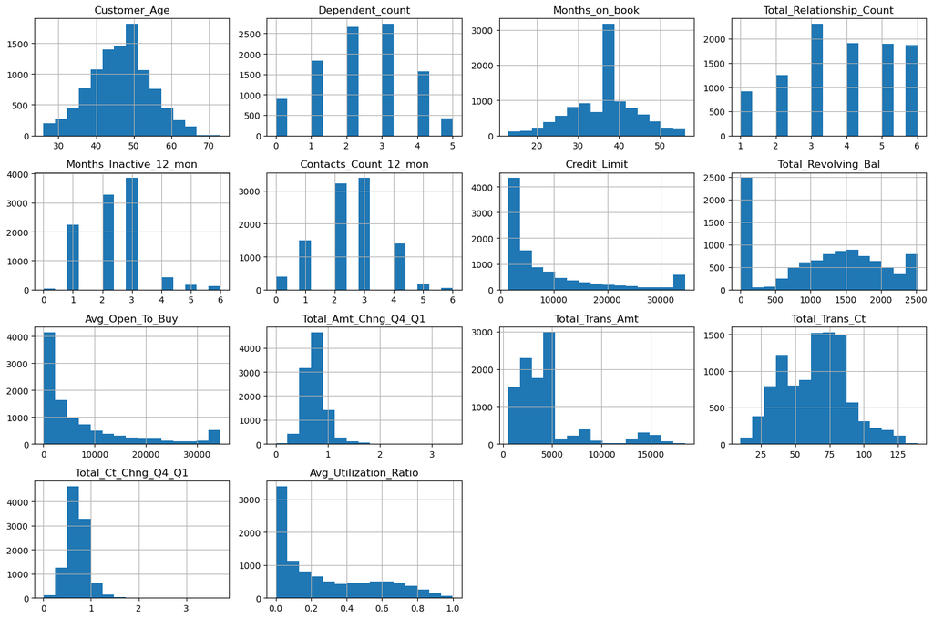

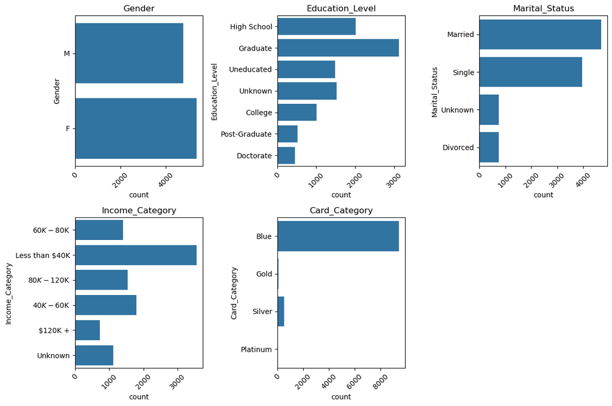

```python
# Plotting the distribution of numerical features
numerical_columns = ['Customer_Age', 'Dependent_count', 'Months_on_book', 'Total_Relationship_Count',
                     'Months_Inactive_12_mon', 'Contacts_Count_12_mon', 'Credit_Limit', 'Total_Revolving_Bal',
                     'Avg_Open_To_Buy', 'Total_Amt_Chng_Q4_Q1', 'Total_Trans_Amt', 'Total_Trans_Ct',
                     'Total_Ct_Chng_Q4_Q1', 'Avg_Utilization_Ratio']

data[numerical_columns].hist(bins=15, figsize=(15, 10), layout=(4, 4))
plt.tight_layout()
plt.show()

# Plotting the categorical features
categorical_columns = ['Gender', 'Education_Level', 'Marital_Status', 'Income_Category', 'Card_Category']

plt.figure(figsize=(12, 8))
for i, col in enumerate(categorical_columns, 1):
    plt.subplot(2, 3, i)
    sns.countplot(data[col])
    plt.title(col)
    plt.xticks(rotation=45)
plt.tight_layout()
plt.show()
```

**Explanation**

- This code plots histograms for numerical features and count plots for categorical features to understand their distributions.
- Use these plots to identify any skewed distributions or outliers

**4. PROCESS DATA**

Why Feature Engineering?

To enhance the predictive power of the model. To create new features that may better capture the underlying patterns in the data. To reduce the dimensionality of the data and focus on the most important features.

```python
from sklearn.preprocessing import LabelEncoder, StandardScaler

# Encode categorical variables
label_encoder = LabelEncoder()
data['Gender'] = label_encoder.fit_transform(data['Gender'])
data['Education_Level'] = label_encoder.fit_transform(data['Education_Level'])
data['Marital_Status'] = label_encoder.fit_transform(data['Marital_Status'])
data['Income_Category'] = label_encoder.fit_transform(data['Income_Category'])
data['Card_Category'] = label_encoder.fit_transform(data['Card_Category'])

# Separate features and target variable
X = data.drop(columns=['Attrition_Flag', 'CLIENTNUM'])  # Features
y = data['Attrition_Flag']  # Target variable

# Scale numerical features
scaler = StandardScaler()
X[numerical_columns] = scaler.fit_transform(X[numerical_columns])

# Check the first few rows of processed data
X.head()
```

|  | Customer_Age | Gender | Dependent_count | Education_Level | Marital_Status | Income_Category | Card_Category | Months_on_book | Total_Relationship_Count | Months_Inactive_12_mon | ... | Credit_Limit | Total_Revolving_Bal | Avg_Open_To_Buy | Total_Amt_Chng_Q4_Q1 | Total_Trans_Amt | Total_Trans_Ct | Total_Ct_Chng_Q4_Q1 | Avg_Utilization_Ratio | Naive_Bayes_Classifier_Attrition_Flag_Card_Category_Contacts_Count_12_mon_Dependent_count_Education_Level_Months_Inactive_12_mon_1 | Naive_Bayes_Classifier_Attrition_Flag_Card_Category_Contacts_Count_12_mon_Dependent_count_Education_Level_Months_Inactive_12_mon_2 |
| --- | --- | --- | --- | --- | --- | --- | --- | --- | --- | --- | --- | --- | --- | --- | --- | --- | --- | --- | --- | --- | --- |
| 0 | -0.165406 | 1 | 0.503368 | 3 | 1 | 2 | 0 | 0.384621 | 0.763943 | -1.327136 | ... | 0.446622 | -0.473422 | 0.488971 | 2.623494 | -0.959707 | -0.973895 | 3.834003 | -0.775882 | 0.000093 | 0.99991 |
| 1 | 0.333570 | 0 | 2.043199 | 2 | 2 | 4 | 0 | 1.010715 | 1.407306 | -1.327136 | ... | -0.041367 | -0.366667 | -0.008486 | 3.563293 | -0.916433 | -1.357340 | 12.608573 | -0.616276 | 0.000057 | 0.99994 |
| 2 | 0.583058 | 1 | 0.503368 | 2 | 1 | 3 | 0 | 0.008965 | 0.120579 | -1.327136 | ... | -0.573698 | -1.426858 | -0.445658 | 8.367214 | -0.740982 | -1.911206 | 6.807864 | -0.997155 | 0.000021 | 0.99998 |
| 3 | -0.789126 | 0 | 1.273283 | 3 | 3 | 4 | 0 | -0.241473 | -0.522785 | 1.641478 | ... | -0.585251 | 1.661686 | -0.734100 | 2.942843 | -0.951758 | -1.911206 | 6.807864 | 1.759686 | 0.000134 | 0.99987 |
| 4 | -0.789126 | 1 | 0.503368 | 5 | 1 | 2 | 0 | -1.869317 | 0.763943 | -1.327136 | ... | -0.430877 | -1.426858 | -0.302868 | 6.455682 | -1.056263 | -1.570365 | 7.509325 | -0.997155 | 0.000022 | 0.99998 |

5 rows × 21 columns

**Explanation**

- This code encodes categorical variables into numerical values and scales numerical features for better model performance.

It also separates features (X) and the target variable (y).

**5. SPLIT THE DATA INTO TRANING AND TESTING SETS**

In this step, we will split the data into training and testing sets. The training set is used to train the model, while the testing set is used to evaluate its performance.

Why Split the Data?

To train the model on a subset of data and test its performance on unseen data. To prevent overfitting and assess how well the model generalizes to new data. To ensure a fair evaluation of the model's performance.

```python
from sklearn.model_selection import train_test_split

# Split the data into training and testing sets
X_train, X_test, y_train, y_test = train_test_split(X, y, test_size=0.2, random_state=42)

# Check the shape of the training and testing sets
X_train.shape, X_test.shape, y_train.shape, y_test.shape
```

```
((8101, 21), (2026, 21), (8101,), (2026,))
```

**TRAINING SETS** The training set is a portion of the dataset that is used to train or fit the machine learning model.

**TESTING SETS** The testing set is a separate portion of the dataset that is used to evaluate the performance of the trained model.

**Explanation**

- This code splits the dataset into training (80%) and testing (20%) sets using train_test_split.
- The 'random_state' parameter ensures reproducibility.

**6. TRAIN A CLASSIFICATION MODEL**

**Build and Evaluate a Random Forest Model**

In this step, we will build a Random Forest model to predict customer churn. Random Forest is a popular ensemble learning method that combines multiple decision trees to improve model accuracy and reduce overfitting.

**Why Random Forest?**

- It provides high accuracy.
- It's robust against overfitting.
- It can handle both numerical and categorical data.

```python
from sklearn.ensemble import RandomForestClassifier
from sklearn.metrics import accuracy_score, confusion_matrix, classification_report

# Initialize the Random Forest model
rf = RandomForestClassifier(random_state=42)

# Train the model on the training set
rf.fit(X_train, y_train)

# Predict on the test set
y_pred_rf = rf.predict(X_test)

# Evaluate the Random Forest model
print("Random Forest Model Evaluation:")
print("Accuracy:", accuracy_score(y_test, y_pred_rf))
print("Confusion Matrix:\n", confusion_matrix(y_test, y_pred_rf))
print("Classification Report:\n", classification_report(y_test, y_pred_rf))
```

```
Random Forest Model Evaluation:
Accuracy: 1.0
Confusion Matrix:
 [[ 327    0]
 [   0 1699]]
Classification Report:
                    precision    recall  f1-score   support

Attrited Customer       1.00      1.00      1.00       327
Existing Customer       1.00      1.00      1.00      1699

         accuracy                           1.00      2026
        macro avg       1.00      1.00      1.00      2026
     weighted avg       1.00      1.00      1.00      2026
```

**RANDOM FOREST MODEL** is a popular machine learning algorithm used for both classification and regression tasks. It is an ensemble learning method, which means it combines multiple algorithms to create a more powerful model.

**Explanation**

- This code initializes and trains a Random Forest model, then evaluates it using accuracy, confusion matrix, and classification report.

**7.Perform Hyperparameter Tuning**

In this step Optimize the Random Forest model parameters to improve performance.

```python
from sklearn.model_selection import GridSearchCV

# Define the parameter grid
param_grid = {
    'n_estimators': [100, 200, 300],
    'max_depth': [None, 10, 20, 30],
    'min_samples_split': [2, 5, 10],
    'min_samples_leaf': [1, 2, 4]
}

# Initialize GridSearchCV
grid_search = GridSearchCV(estimator=rf, param_grid=param_grid, cv=3, n_jobs=-1, verbose=2)

# Fit GridSearchCV
grid_search.fit(X_train, y_train)

# Best parameters and best score
print("Best Parameters:", grid_search.best_params_)
print("Best Score:", grid_search.best_score_)
```

```
Fitting 3 folds for each of 108 candidates, totalling 324 fits
Best Parameters: {'max_depth': None, 'min_samples_leaf': 1, 'min_samples_split': 2, 'n_estimators': 100}
Best Score: 1.0
```

**Explanation**

**8. PERFORM FEATURE SELECTION**

In this step, we will use Recursive Feature Elimination (RFE) to select the most important features for our model. RFE is a technique that recursively removes the least important features to improve model performance.

Why Feature Selection with RFE?

To reduce the complexity of the model. To improve the model's accuracy by selecting only the most important features. To enhance the model's interpretability.

```python
from sklearn.feature_selection import RFE
from sklearn.linear_model import LogisticRegression

# Initialize Logistic Regression model
log_reg = LogisticRegression(max_iter=1000, random_state=42)

# Initialize RFE with the model and number of features to select
rfe = RFE(estimator=log_reg, n_features_to_select=10, step=1)

# Fit RFE
rfe.fit(X_train, y_train)

# Get the ranking of features
ranking = rfe.ranking_

# Create a DataFrame for feature rankings
rfe_features = pd.DataFrame({'Feature': X_train.columns, 'Ranking': ranking})
rfe_features = rfe_features.sort_values(by='Ranking')

# Print the features with their rankings
print(rfe_features)
```

```
                                              Feature  Ranking
10                              Contacts_Count_12_mon        1
17                                Total_Ct_Chng_Q4_Q1        1
16                                     Total_Trans_Ct        1
15                                    Total_Trans_Amt        1
12                                Total_Revolving_Bal        1
19  Naive_Bayes_Classifier_Attrition_Flag_Card_Cat...        1
9                              Months_Inactive_12_mon        1
8                            Total_Relationship_Count        1
20  Naive_Bayes_Classifier_Attrition_Flag_Card_Cat...        1
1                                              Gender        1
18                              Avg_Utilization_Ratio        2
14                               Total_Amt_Chng_Q4_Q1        3
7                                      Months_on_book        4
4                                      Marital_Status        5
5                                     Income_Category        6
2                                     Dependent_count        7
11                                       Credit_Limit        8
0                                        Customer_Age        9
6                                       Card_Category       10
13                                    Avg_Open_To_Buy       11
3                                     Education_Level       12
```

**Recursive Feature Elimination (RFE)** is a feature selection technique used in machine learning to identify the most important features for a model. The main idea behind RFE is to recursively remove the least important features and build the model with the remaining features. The process is repeated until the desired number of features is reached.

**Explanation**

- This code uses Recursive Feature Elimination (RFE) with Logistic Regression to select the top 10 features that contribute most to predicting churn.

**9. EVALUATE THE MODEL WITH SELECTED FEATURES**

In this step, we will evaluate the model using the selected features after feature selection. This helps to compare the model's performance before and after feature selection.

Why Evaluate the Model with Selected Features?

To assess the impact of feature selection on model performance. To determine if the reduced feature set improves accuracy, precision, recall, and F1-score. To finalize the model with the best-performing feature set.

```python
# Select the top 10 features
selected_features = rfe_features[rfe_features['Ranking'] == 1]['Feature'].tolist()
X_train_selected = X_train[selected_features]
X_test_selected = X_test[selected_features]

# Train the model with selected features
rf.fit(X_train_selected, y_train)

# Predict on the test set with selected features
y_pred_rf_selected = rf.predict(X_test_selected)

# Evaluate the model with selected features
print("Random Forest Model with Selected Features Evaluation:")
print("Accuracy:", accuracy_score(y_test, y_pred_rf_selected))
print("Confusion Matrix:\n", confusion_matrix(y_test, y_pred_rf_selected))
print("Classification Report:\n", classification_report(y_test, y_pred_rf_selected))
```

```
Random Forest Model with Selected Features Evaluation:
Accuracy: 1.0
Confusion Matrix:
 [[ 327    0]
 [   0 1699]]
Classification Report:
                    precision    recall  f1-score   support

Attrited Customer       1.00      1.00      1.00       327
Existing Customer       1.00      1.00      1.00      1699

         accuracy                           1.00      2026
        macro avg       1.00      1.00      1.00      2026
     weighted avg       1.00      1.00      1.00      2026
```

**Explanation**

- This code trains and evaluates the model using only the selected features to see if performance improves or remains consistent.

# SUMMARY OF FINDINGS

The Churn Prediction Model project aimed to identify customers at risk of discontinuing their relationship with the bank. Through a systematic approach encompassing data exploration, preprocessing, modeling, and evaluation, several key insights and outcomes were achieved:

**1. Data Exploration**

- Dataset Overview: The dataset contains various features related to customer demographics and transactions, including attributes like age, income, credit limit, and churn status.
- Data Quality: The dataset was clean with no missing values, facilitating a smooth preprocessing phase.

**2. Exploratory Data Analysis (EDA)**

**3. Preprocessing and Feature Engineering**

**4. Model Training and Evaluation**

**5. Feature Importance**

## Improvement Strategy

- Implement cross-validation to further validate and enhance the model's robustness.
- Compare the performance of other classification algorithms like Gradient Boosting and SVM.
- Fine-tune hyperparameters to improve model accuracy and efficiency.
- Add new features or external data (e.g., customer feedback) to enrich the model.
- Deploy the model in a production environment for real-time churn prediction.
- Continuously monitor and retrain the model with new data to maintain accuracy.
- Use model insights to develop personalized retention strategies for at-risk customers.